Sample / Mockup · 일반용(제주 TOU) 분석 리포트 · Portfolio Demo

# ⚡ 일반용 전력 사용량 분석 보고서 (UI/UX Mockup)

스마트 에너지 관리 시스템

2026-09-09

# ⚡ 일반용 전력 사용량 06월 분석 보고서 (UI/UX Mockup)

본 리포트는 Mockup 이며, 샘플 데이터로 생성되었습니다.

스마트 에너지 관리 시스템 | 2026년 06월 운영성과

# 📋 고객 및 계약 정보

### 📋 고객 기본 정보

**👤 고객명:** 샘플공공기관A

**🔢 고객번호:** S16095120

**📑 계약종별:** 일반용(을)고압A

**⚡ 계약전력:** 400kw

### 💰 시간대별 전력량 요금

[output not shown]

### ⏰ 부하 시간대 안내 (제주 기준)

- **경부하:** 22:00 ~ 08:00 (10시간)
- **중간부하:** 08:00 ~ 16:00 (8시간)
- **최대부하:** 16:00 ~ 22:00 (6시간)

※ 토요일: 최대부하 → 중간부하 / 공휴일: 최대부하/중간부하 → 경부하

# 📊 종합 대시보드

## ⚡ 26년 06월 운영 성과

분석 기간: 2026.05.15 ~ 2026.06.14 (31일)

⚡

총 전력사용량

27,564

kWh

📊 일평균: **889** kWh

📊

최대수요

78

kW

활용률

19.5%

📅 발생일: **05월 27일**

💰

전력량요금

340

만원

💡 절감 잠재력: **~34 만원** (10% 절감 시)

🌱

탄소 배출량

11.5

톤 CO₂

나무 환산

🌲 523그루

📊 배출계수: 0.4173 kgCO₂/kWh (ESG/기후공시 기준)

💵

kWh당 평균단가

123.4원

🕐

피크 빈발 시간

14시

🌡️

평균기온

17.7°C

📅

분석 기간

31일

⚖️ 부하율

47.5%

0% 30% 50% 70% 100%

💡 부하율이란?

**전력을 하루 종일 얼마나 고르게 사용했는지**를 보여주는 지표입니다.

**📊 쉬운 예시**  
• 하루 최대 100kW를 사용하는 건물이 있다고 가정합니다.  
• 만약 24시간 내내 100kW를 쓴다면 → 부하율 **100%**  
• 실제로는 낮에만 많이 쓰고 밤에는 적게 쓰므로 → 부하율 **47.5%**

**📈 의미**  
• **높을수록**: 24시간 고르게 사용 (공장, 냉동창고 등)  
• **낮을수록**: 특정 시간에 집중 사용 (일반 사무실)

**📐 산정식**

총 사용량 ÷ (최대수요 × 24h × 일수) × 100  
= 27,564kWh ÷ (78kW × 24h × 31일) × 100  
**= 47.5%**

✅ 양호: 일반 건물 기준 적정 수준입니다. 전력을 비교적 균일하게 사용하고 있습니다.

📊 설비 활용 현황

충분

활용률 19.5%

0% 40% 60% 80% 90% 100%

💡 설비 활용률이란?

**설비(변압기) 용량 대비 실제 최대수요 비율**을 나타냅니다.

**📐 산정식**  
최대수요 ÷ 설비용량 × 100  
= 78kW ÷ 400kW × 100  
**= 19.5%**

**📊 상태 기준**  
• **적정** (60~80%): 안정적 운영 + 적정 여유 확보  
• **양호** (50~60%, 80~90%): 효율적 활용 상태  
• **주의** (90% 이상): 피크 시 용량 초과 가능성  
• **여유** (40~50%): 부하 증설 여력 있음  
• **충분** (40% 미만): 충분한 여유 용량 보유

※ 고압 고객의 계약전력은 변압기 용량과 연동되어 설비 교체 없이는 변경이 제한됩니다.

💡 충분: 설비 용량에 충분한 여유가 있습니다. 향후 부하 증설 시 추가 설비 투자 없이 대응 가능합니다.

경부하 12,402 kWh (45%)

중간부하 10,135 kWh (36.8%)

최대부하 5,080 kWh (18.4%)

# 📈 일별 전력 사용량 추이

[interactive chart not shown]

# ⚡ 시간대별 부하 분석

## 부하별 전력 사용량 구성

[interactive chart not shown]

## 💡 부하 분석 인사이트

### 💰 부하 이전 시뮬레이션

**시나리오:** 최대부하 시간대 사용량의 10%를 중간부하로 이전

**이전 가능량:** 508 kWh

**예상 절감액:** 23,783원/월

※ 실제 절감액은 운영 환경에 따라 달라질 수 있습니다.

# 📊 최대수요 관리

[interactive chart not shown]

### 💡 최대수요 분석

📊 **평균 최대수요:** 55.0 kW (계약전력의 13.7%)

⚠️ **고부하 일수:** 0일 (계약전력 90% 초과)

💡 **여유 전력:** 322.0 kW

# ⚡ 피크 발생 상세 분석

[interactive chart not shown]

### 📊 피크 발생 요일 분석

[interactive chart not shown]

### 💡 피크 관리 인사이트

#### ⚡ 피크 발생 패턴 분석

**🕐 피크 집중 시간**

- 1위: **14시** (8회, 25.8%)
- 2위: **16시** (6회, 19.4%)
- 3위: **15시** (5회, 16.1%)

# 🌡️ 시간대별 전력 사용 패턴

[interactive chart not shown]

# 📅 시간-요일별 히트맵

[interactive chart not shown]

# 📆 요일별 사용 패턴 분석

[interactive chart not shown]

### 💡 요일별 패턴 인사이트

#### 📆 요일별 사용 패턴 분석

**📈 사용량 순위**

**📊 주중 vs 주말**

**📉 변동성 분석**

- 가장 불안정: **일요일** (CV: 29.1%)
- 가장 안정적: **금요일** (CV: 6.2%)

# ❄️ HDD/CDD 분석

[interactive chart not shown]

### 🎯 밸런스 포인트 산정 방법

#### 📐 밸런스 포인트란?

**밸런스 포인트(Balance Point)**는 건물의 냉난방 부하가 발생하기 시작하는 외기온도 기준점입니다. 이 온도를 기준으로 외기가 더 추워지면 난방 부하가, 더 더워지면 냉방 부하가 발생합니다.

#### 🔬 산정 방법

본 분석에서는 **회귀분석 기반 자동 추정** 방식을 사용합니다:

1. 후보 온도 범위 설정 (난방: 14~22°C, 냉방: 22~28°C)
2. 각 후보 온도에 대해 HDD/CDD 계산 후 전력 사용량과 회귀분석 수행
3. **예측 오차(RMSE)가 가장 작은 온도**를 밸런스 포인트로 선정
4. → “이 온도를 기준으로 했을 때 전력 사용량 변화를 가장 잘 설명한다”

🔴

18.0°C

**난방 밸런스 포인트**

이 온도 이하 → 난방 부하 발생

**1°C 하락당**  
전력 +71 kWh/일 (**+8.3%**)

🔵

이 온도 이상 → 냉방 부하 발생

### 📊 HDD/CDD 분석 결과

#### 📈 기간 통계

• **총 누적 HDD:** 21.2°C·days (20일)

• **총 누적 CDD:** 0.0°C·days (0일)

• **중립 구간:** 11일

• **HDD-전력 상관계수:** 0.28

#### ⚡ 에너지 사용 패턴

• **HDD(난방):** 값이 커질수록 사용량이 늘어나는 경향

→ HDD 1°C·day 증가 시 평균 **71.0 kWh** 변화

#### 💡 시사점

• 비업무시간 잔류가동/자동모드 과다 여부를 점검해 주세요.

# 🌡️ 엔탈피 기반 공조부하 분석

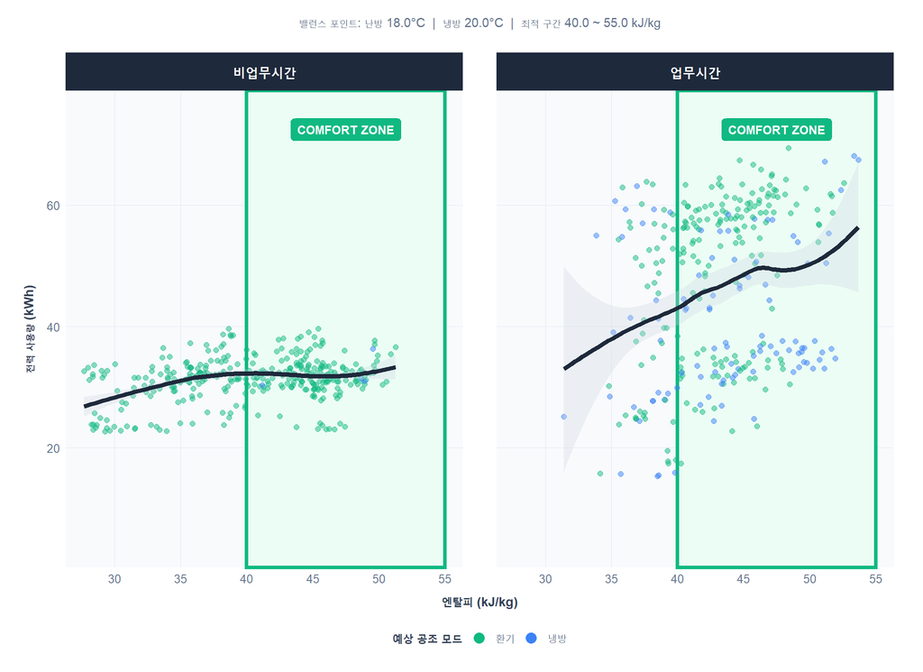

### 💡 엔탈피 분석 인사이트

#### 🌡️ 엔탈피 분석이란?

**엔탈피(Enthalpy)**는 **온도와 습도를 동시에 고려한 복합 지표**입니다. 단순히 온도만 보면 놓치기 쉬운 **“습도로 인한 불쾌감과 냉방 부하”**까지 반영합니다.

**🌧️ 고습도** (70%↑)

같은 온도에서 냉방 부하 20~30% 증가

**☀️ 저습도** (40%↓)

냉방 효율 상승, 겨울철 가습 필요

#### 🌿 COMFORT ZONE (최적 효율 구간)

엔탈피 기준

40.0 ~ 55.0 kJ/kg

외기온도 기준 (참고)

18 ~ 20°C

#### 📈 분석 기간 예상 공조 모드 분포

**※ 참고:** 공조 모드는 외기 조건(온도, 습도, 엔탈피)을 기반으로 **예상한 값**입니다. 실제 냉난방 가동 여부는 건물 관리 정책에 따라 다를 수 있습니다.

0.0%

🔴 난방 필요

83.8%

🟢 자연환기

16.2%

🔵 냉방 필요

⏰ 업무시간(09~18시)은 비업무시간 대비 평균 **46.5% 더 많이** 사용합니다.

# 📅 계절별 전력 사용 패턴 분석

### 💡 계절별 분석 인사이트

#### 🍂 봄/가을철 전력 사용 패턴

- **평균 일일 사용량:** 891 kWh
- **이상점 발생:** 총 2일 (과다: 0일, 과소: 2일)
- ⚠️ 이상점이 발생한 날은 특별 행사, 휴일, 설비 점검 등의 영향일 수 있습니다.
- 💡 **절감 팁:** 환절기에는 자연환기 활용과 공조 스케줄 최적화가 효과적입니다.

# 🌱 탄소 배출량 추정

[interactive chart not shown]

### 🌳 탄소 배출 인사이트

#### 🌱 탄소 배출 현황

| 분석기간 총 배출량 | **11.5 톤** CO₂ |
| --- | --- |
| 일평균 배출량 | **371 kg** CO₂ |
| 총 전력 사용량 | **27,564 kWh** |
| 배출계수 | 0.4173 kgCO₂/kWh (ESG/기후공시 기준) |

#### 🌳 환경 영향 환산

**🌲 523**

그루의 나무가 1년간 흡수하는 CO₂와 동일

(나무 1그루 연간 CO₂ 흡수량: 약 22kg 기준)

#### 💡 탄소 저감 잠재력

| 전력 5% 절감 시 | **-0.58 톤** CO₂ |
| --- | --- |
| 전력 10% 절감 시 | **-1.15 톤** CO₂ |
| **💡 권장사항** |  |
| 피크 시간대 부하 분산으로 연간 약 **6.9 톤** CO₂ 저감 가능 |  |

# 💰 요금 분석

## 일별 전력량 요금 추이

[interactive chart not shown]

## 시간대별 요금 구성

[interactive chart not shown]

### 💡 요금 분석 인사이트

#### 📊 요금 현황

- **분석기간 총 요금:** 340만원
- **일평균 요금:** 11만원
- **최고 요금일:** 2026-06-04 (17.4만원)
- **최저 요금일:** 2026-05-17 (3.5만원)
- **요금 변동폭:** 13.9만원 (CV: 36.4%)

#### 📅 주중/주말 비교

- **주중 평균:** 13만원/일
- **주말 평균:** 6.8만원/일
- 주중이 주말 대비 **91.1%** 더 높음

#### ⏰ 시간대별 요금

- **경부하 (22~08시):** 116.1만원 (33.9%)
- **중간부하:** 131.6만원 (38.5%)
- **최대부하 (피크):** 94.6만원 (27.6%)

#### 💡 요금 절감 시나리오

**🎯 시나리오 1: 최대부하 10% 절감**

피크 시간대 사용량 10% 감축 시  
약 9.5만원/기간 절감 가능

**🔄 시나리오 2: 부하 이전 (Peak → Off-Peak)**

최대부하 5%를 경부하 시간대로 전환 시  
약 3.1만원/기간 절감 가능

**✅ 실천 방안:**

- 경부하 비중(33.9%)이 적정 수준입니다. 현재 패턴을 유지하세요.
- 요금 변동성(CV 36.4%)이 높습니다. 일별 사용량 편차 원인을 분석하세요.

# 📊 청구요금 비교 분석

[interactive chart not shown]

### 📊 청구요금 상세 비교

#### 📅 당월

| 기본요금 | **759,853**원 |
| --- | --- |
| 사용량요금 | **3,429,266**원 |
| 기타요금 | **957,777**원 |
| **총 청구요금** | **5,146,896**원 |

#### 📅 전월

| 기본요금 | **759,939**원 |
| --- | --- |
| 사용량요금 | **2,006,775**원 |
| 기타요금 | **629,919**원 |
| **총 청구요금** | **3,396,633**원 |

#### 📅 전년동월

| 기본요금 | **709,615**원 |
| --- | --- |
| 사용량요금 | **2,345,456**원 |
| 기타요금 | **677,853**원 |
| **총 청구요금** | **3,732,924**원 |

#### 📈 변화 분석

전월 대비

**📈 +51.5%**

1,750,263원

전년동월 대비

**📈 +37.9%**

1,413,972원

# 🔮 전력 사용량 예측 분석

[interactive chart not shown]

### 💡 예측 분석 요약

### 🔮 AI 예측 결과

📊 **예측 기간 총 사용량:** 32,890 kWh

📈 **일평균 예측:** 1,096 kWh

⬆️ **최대 예측:** 1,318 kWh (07/13)

⬇️ **최소 예측:** 797 kWh (06/21)

※ Prophet, ARIMA, XGBoost 모델의 앙상블 예측 결과입니다.

# 📋 다음 달 예상 청구 내역

[interactive chart not shown]

# 💡 절감 방안 및 권고사항

[interactive chart not shown]

## ☀️ 여름철 에너지 관리

현재 **26년 06월월** 기준 | 권장 실내온도: **24~26°C**

### 📋 핵심 관리 포인트

- 냉방 부하 집중 - 실내온도 26°C 유지로 냉방에너지 10~15% 절감
- 피크 시간대(14~17시) 집중 관리 - 냉방 사전가동 활용
- 차양·단열 강화 - 블라인드, 차양막으로 일사열 차단
- 야간 예냉 운전 - 경부하 시간대 건물 축냉으로 주간 피크 분산

### ⚡ 즉시 실행 권장

✓ 냉방기 효율 점검 ✓ 피크시간 부하 분산 ✓ 실외기 청소

[interactive chart not shown]

### 🍂 다음 시즌 준비: 가을철 에너지 관리

다가오는 계절을 대비하여 미리 준비하면 효과적입니다.

🔧  
**난방 설비 점검**

🔧  
**단열재 점검**

🔧  
**창호 기밀 확인**

## 💰 연간 절감 잠재력 분석

### ⚠️ 전월 대비 사용량 급증 감지

계절 변화에 따른 자연 증가인지, 설비 이상이나 낭비 요소가 있는지 점검을 권장합니다.

최대수요 5% 절감 시

약 28만원

피크 관리로 기본요금 절감

최대부하 10% → 중간부하 이전

약 29만원

시간대별 요금 차이 활용

총 절감 잠재력

연 56만원 💰

위 방안 종합 적용 시

### 📌 상시 적용 가능한 절감 방안

#### 💡 에너지 효율 개선

- LED 조명 교체 및 조도 센서 활용
- 공조 설비 정기 점검 및 필터 교체
- 대기전력 차단 콘센트 활용

#### 🔄 부하 이전 전략

- 경부하 시간대 예냉/예열 운전 활용
- 전기온수기 등 축열 설비 야간 가동
- 대용량 설비 가동시간 조정

#### 📊 스마트 모니터링

- 전력 모니터링 시스템으로 실시간 사용량 파악
- 구역별/설비별 사용량 분석
- 이상 사용 패턴 자동 알림 설정

# 📊 상세 데이터 테이블

| 일자 | 총사용량(kWh) | 최대수요(kW) | 경부하(kWh) | 중간부하(kWh) | 최대부하(kWh) | 요금(원) |
| --- | --- | --- | --- | --- | --- | --- |
| 06/14 (일) | 756 | 44 | 783 | 0 | 0 | 70,095 |
| 06/13 (토) | 747 | 38 | 297 | 458 | 0 | 95,824 |
| 06/12 (금) | 993 | 61 | 296 | 447 | 264 | 148,189 |
| 06/11 (목) | 934 | 61 | 241 | 427 | 256 | 146,485 |
| 06/10 (수) | 1,010 | 67 | 295 | 460 | 240 | 151,493 |
| 06/09 (화) | 1,068 | 69 | 326 | 479 | 272 | 157,997 |
| 06/08 (월) | 1,047 | 66 | 319 | 457 | 281 | 158,729 |
| 06/07 (일) | 780 | 40 | 781 | 0 | 0 | 69,970 |
| 06/06 (토) | 666 | 35 | 640 | 0 | 0 | 59,722 |
| 06/05 (금) | 1,105 | 66 | 336 | 461 | 272 | 161,655 |
| 06/04 (목) | 1,086 | 75 | 324 | 477 | 302 | 173,751 |
| 06/03 (수) | 797 | 45 | 825 | 0 | 0 | 75,386 |
| 06/02 (화) | 1,064 | 69 | 327 | 476 | 294 | 168,287 |
| 06/01 (월) | 1,009 | 68 | 312 | 430 | 282 | 159,700 |
| 05/31 (일) | 704 | 40 | 727 | 0 | 0 | 65,774 |
| 05/30 (토) | 646 | 37 | 282 | 385 | 0 | 69,559 |
| 05/29 (금) | 1,047 | 65 | 334 | 436 | 262 | 118,259 |
| 05/28 (목) | 1,097 | 67 | 334 | 462 | 273 | 128,543 |
| 05/27 (수) | 1,176 | 78 | 344 | 505 | 293 | 131,725 |
| 05/26 (화) | 1,157 | 73 | 338 | 522 | 306 | 134,541 |
| 05/25 (월) | 790 | 42 | 784 | 0 | 0 | 72,462 |
| 05/24 (일) | 752 | 36 | 746 | 0 | 0 | 69,850 |
| 05/23 (토) | 825 | 49 | 316 | 496 | 0 | 84,325 |
| 05/22 (금) | 1,001 | 55 | 316 | 405 | 245 | 115,117 |
| 05/21 (목) | 1,040 | 69 | 337 | 462 | 283 | 123,461 |
| 05/20 (수) | 1,010 | 64 | 269 | 462 | 276 | 120,586 |
| 05/19 (화) | 717 | 52 | 174 | 350 | 222 | 87,228 |
| 05/18 (월) | 689 | 52 | 152 | 325 | 202 | 78,847 |
| 05/17 (일) | 367 | 24 | 374 | 0 | 0 | 35,056 |
| 05/16 (토) | 559 | 33 | 213 | 349 | 0 | 58,092 |
| 05/15 (금) | 927 | 64 | 260 | 405 | 254 | 109,695 |

### 📊 보고서 생성 정보

**생성일시:** 2026년 09월 09일 13:08:34  
**분석 기간:** 2026.05.15 ~ 2026.06.14  
**데이터 건수:** 일별 31건 | 시간별 744건

**계약 정보:** 일반용(을)고압A | 계약전력 400 kW

**분석 도구:** R 4.x | plotly | ggplot2 | dplyr | kableExtra

이 보고서는 인터랙티브 차트를 포함하고 있습니다.  
차트에 마우스를 올려 상세 정보를 확인하고, 확대/축소 등의 기능을 활용하세요.  
💡 **Tip:** 그래프 범례를 클릭하면 특정 데이터를 숨기거나 표시할 수 있습니다.